# Chapter 3: Probability Theory and Bayesian Foundations

2026-02-25

# 1 Probability Axioms and Set Operations

## 1.1 Probability Axioms

Probability is built on three foundational rules (Kolmogorov’s axioms):

| Axiom | Statement | Formal |
| --- | --- | --- |
| **Non-negativity** | Probability is never negative | $P(A) \geq 0$ |
| **Normalisation** | The certain event has probability 1 | $P(\Omega) = 1$ |
| **Additivity** | Mutually exclusive events: add their probabilities | $P(A \cup B) = P(A) + P(B)$ if $A \cap B = \emptyset$ |

Everything else in probability theory follows logically from these three rules.

## 1.2 Set Operations on Events

Think of each event as a set of outcomes in the sample space $\Omega$.

| Operation | Symbol | Meaning | Example |
| --- | --- | --- | --- |
| **Union** | $A \cup B$ | *A* or *B* (or both) occur | Rolling a 1 *or* a 2 on a die |
| **Intersection** | $A \cap B$ | *A* and *B* both occur | Card is red *and* a face card |
| **Complement** | $A^c$ | *A* does not occur | Not rolling a 6 |

### 1.2.1 General Addition Rule

When events are *not* mutually exclusive you must subtract the overlap:

$$P(A \cup B) = P(A) + P(B) - P(A \cap
B)$$

# 2 Conditional Probability

## 2.1 Definition

**Conditional probability** answers: *“Given that B has already happened, how likely is A?”*

$$P(A \mid B) = \frac{P(A \cap B)}{P(B)},
\quad P(B) > 0$$

Conditioning *narrows the sample space* down to the outcomes where B is true, then re-evaluates the proportion where A is also true.

> **Intuition:** Imagine 100 students. 60 passed the exam, and 40 passed *and* studied. Given a student passed, the probability they studied is $40/60 \approx 0.67$.

## 2.2 Law of Total Probability

If events $B_1, B_2, \ldots, B_k$ partition the sample space (mutually exclusive, exhaustive), then:

$$P(A) = \sum_{i=1}^{k} P(A \mid B_i)\,
P(B_i)$$

**Plain English:** Break a complex event into simpler paths, compute the probability along each path, then add them up.

**Example:** A student can pass an exam by passing Theory *or* Practical:

$$P(\text{Pass}) = P(\text{Pass} \mid
\text{Theory})\,P(\text{Theory}) + P(\text{Pass} \mid
\text{Practical})\,P(\text{Practical})$$

# 3 Bayes’ Theorem

**Bayes’ theorem** lets you *update* a prior belief about an event when new evidence arrives.

$$P(A \mid B) = \frac{P(B \mid A)\,
P(A)}{P(B)}$$

| Term | Name | Meaning |
| --- | --- | --- |
| $P(A)$ | **Prior** | Belief about A *before* seeing B |
| $P(B \mid A)$ | **Likelihood** | How probable is the evidence B if A is true? |
| $P(B)$ | **Marginal** | Overall probability of observing B |
| $P(A \mid B)$ | **Posterior** | Updated belief about A *after* seeing B |

## 3.1 Bayesian Updating Logic

The posterior from one analysis becomes the prior for the next, allowing beliefs to be **refined iteratively** as more data arrives:

$$\underbrace{P(A \mid B_1,
B_2)}_{\text{updated posterior}} \propto P(B_2 \mid A)\;\underbrace{P(A
\mid B_1)}_{\text{previous posterior becomes new prior}}$$

## 3.2 Interpretation of Posterior Probabilities

The posterior $P(A \mid B)$ is not fixed — it depends on:

- **How strong the prior is** (how confident you were before).
- **How informative the new data is** (the likelihood ratio $P(B|A) / P(B|\neg A)$).

> **Example:** A medical test for a rare disease has 99% sensitivity. Even so, if the disease affects only 1 in 10,000 people, a positive test still has a low posterior probability of *actually* having the disease — because the base rate (prior) is so low. This is the **base-rate fallacy**, and Bayes’ theorem is the antidote.

# 4 R-Based Simulation

## 4.1 Monte Carlo Probability Experiments

**Monte Carlo simulation** estimates probabilities by repeating a random experiment thousands of times and counting outcomes — a direct application of the *frequentist* interpretation of probability.

```r
set.seed(42)
n <- 100000   # more simulations → more accurate estimate

# Simulate random integers 1–100
sim_data <- sample(1:100, size = n, replace = TRUE)

# Estimate P(X > 50)
prob_gt50 <- mean(sim_data > 50)
cat("Estimated P(X > 50):", prob_gt50, "\n")
```

```
#> Estimated P(X > 50): 0.49819
```

```r
cat("Theoretical value  : 0.50\n")
```

```
#> Theoretical value  : 0.50
```

As $n \to \infty$, the estimate converges to the true probability. This is the **Law of Large Numbers** in action.

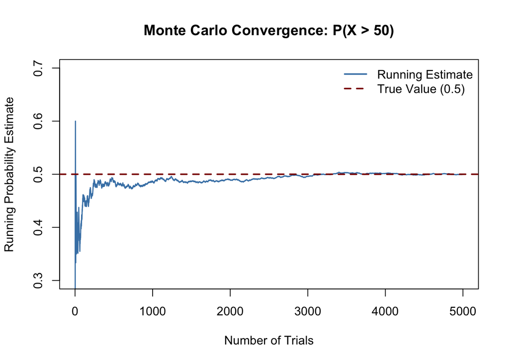

```r
# Visualise convergence: running estimate vs trial number
set.seed(42)
trials   <- sample(1:100, size = 5000, replace = TRUE)
running  <- cumsum(trials > 50) / seq_along(trials)

plot(running,
     type = "l", col = "steelblue", lwd = 1.5,
     ylim = c(0.3, 0.7),
     main = "Monte Carlo Convergence: P(X > 50)",
     xlab = "Number of Trials",
     ylab = "Running Probability Estimate")
abline(h = 0.5, col = "darkred", lwd = 2, lty = 2)
legend("topright",
       legend = c("Running Estimate", "True Value (0.5)"),
       col    = c("steelblue", "darkred"),
       lty    = c(1, 2), lwd = 2, bty = "n")
```

## 4.2 Empirical Validation of Bayes’ Theorem

We validate the conditional probability definition $P(A \mid B) = P(A \cap B) / P(B)$ using simulation, without invoking any formula directly.

```r
set.seed(123)
N <- 100000   # large sample for accurate estimation

# Generate 100,000 random integers 1–100
data <- sample(1:100, size = N, replace = TRUE)

# Define two events
A <- data > 50      # Event A: number > 50
B <- data %% 2 == 0 # Event B: number is even

# --- Step 1: Basic probabilities ---
P_A       <- mean(A)       # P(A)  ≈ 0.50
P_B       <- mean(B)       # P(B)  ≈ 0.50
P_A_and_B <- mean(A & B)   # P(A ∩ B)

# --- Step 2: Empirical conditional probability ---
P_A_given_B_empirical   <- P_A_and_B / P_B

# --- Step 3: Theoretical value ---
# Numbers 51–100 that are even: 25 values out of 50 even numbers → 0.5
P_A_given_B_theoretical <- 0.5

cat("P(A)              :", round(P_A, 4), "\n")
```

```
#> P(A)              : 0.4982
```

```r
cat("P(B)              :", round(P_B, 4), "\n")
```

```
#> P(B)              : 0.4985
```

```r
cat("P(A ∩ B)          :", round(P_A_and_B, 4), "\n")
```

```
#> P(A ∩ B)          : 0.2467
```

```r
cat("P(A|B) empirical  :", round(P_A_given_B_empirical, 4), "\n")
```

```
#> P(A|B) empirical  : 0.4948
```

```r
cat("P(A|B) theoretical:", P_A_given_B_theoretical, "\n")
```

```
#> P(A|B) theoretical: 0.5
```

> **What this shows:** The empirically computed $P(A \mid B)$ closely matches the theoretical value, confirming that the definition of conditional probability works exactly as expected. The small difference is due to random sampling variation.

### 4.2.1 Visualising the Joint Event Space

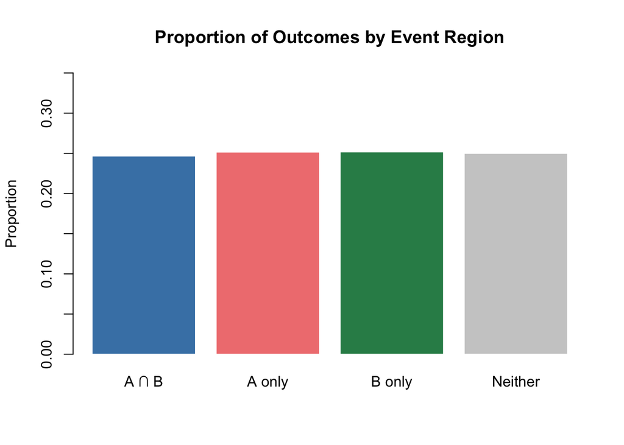

```r
# Proportion of outcomes in each region
region <- ifelse(A & B,  "A ∩ B",
          ifelse(A & !B, "A only",
          ifelse(!A & B, "B only", "Neither")))

counts <- table(region) / N

barplot(counts,
        col    = c("steelblue", "lightcoral", "seagreen", "grey80"),
        border = "white",
        main   = "Proportion of Outcomes by Event Region",
        ylab   = "Proportion",
        ylim   = c(0, 0.35))
```

# 5 Chapter Summary

| Concept | Key Takeaway |
| --- | --- |
| Probability Axioms | Non-negativity, Normalisation, Additivity — the three foundations |
| Union $A \cup B$ | At least one event occurs; subtract overlap if not mutually exclusive |
| Intersection $A \cap B$ | Both events occur simultaneously |
| Complement $A^c$ | The event does *not* occur; $P(A^c) = 1 - P(A)$ |
| Conditional Probability | $P(A \mid B) = P(A \cap B)/P(B)$; narrows sample space to B |
| Law of Total Probability | Decompose complex event through an exhaustive partition |
| Bayes’ Theorem | Posterior $\propto$ Likelihood $\times$ Prior; update beliefs with evidence |
| Monte Carlo | Estimate probability by counting successes over many simulations |
| Law of Large Numbers | Simulated frequency → true probability as $n \to \infty$ |